# Analyzing Text

Unstructured Data Analytics

```r
library(tidyverse)
library(gutenbergr)
library(tidytext)
```

### 5. Term Frequency: simple

To illustrate simple word frequency, let’s re-download the text from the book “The War of the Worlds” by HG Wells:

```r
war_worlds <- gutenberg_download(36, mirror = 'https://gutenberg.pglaf.org/')
war_worlds
```

| gutenberg_id | text |
| --- | --- |
| 36 | cover |
| 36 |  |
| 36 |  |
| 36 |  |
| 36 |  |
| 36 | The War of the Worlds |
| 36 |  |
| 36 | by H. G. Wells |
| 36 |  |
| 36 |  |

[output cut: 6362 more lines]

Next, we tidy the text, remove stop words and get the frequency of each word in the text:

```r
war_worlds %>%
  unnest_tokens(output = word, input = text, token = "words") %>%
  anti_join(stop_words, by = "word") %>%
  count(word, sort = TRUE)
```

| word | n |
| --- | --- |
| martians | 165 |
| people | 159 |
| black | 122 |
| time | 121 |
| road | 105 |
| night | 103 |
| brother | 91 |
| pit | 83 |
| martian | 79 |
| water | 79 |

[output cut: 6342 more lines]

Using the word frequency, we can create a simple word cloud of words that occur at least 25 times. We use the `wordcloud2()` function from the `wordcloud2` package for this.

```r
library(wordcloud2)
war_worlds %>%
  unnest_tokens(output = word, input = text, token = "words") %>%
  anti_join(stop_words, by = "word") %>%
  count(word) %>%
  filter(n >= 25) %>%
  wordcloud2(size = .5, shape = "circle")
```

[interactive chart not shown]

In the previous example, we used word count to represent word frequency for one book.

What if we want to compare books? We can examine 4 different HG Wells books with book ids `35`, `36`, `159` and `5230`:

```r
hgwells <- gutenberg_download(c(35, 36, 159, 5230), meta_fields = "title", mirror = 'https://gutenberg.pglaf.org/')
```

What books did we get? Let’s find out:

```r
hgwells %>%
  distinct(title)
```

| title |
| --- |
| The Time Machine |
| The War of the Worlds |
| The Island of Doctor Moreau |
| The Invisible Man: A Grotesque Romance |

Again, let’s run counts by let’s do it by title

Next let’s do some basic word counts.

```r
hgwells %>%
  unnest_tokens(output = word, input = text, token = "words") %>%
  anti_join(stop_words, by = "word") %>%
  count(title, word) %>%
  arrange(title, desc(n))
```

| title | word | n |
| --- | --- | --- |
| The Invisible Man: A Grotesque Romance | kemp | 213 |
| The Invisible Man: A Grotesque Romance | invisible | 180 |
| The Invisible Man: A Grotesque Romance | door | 169 |
| The Invisible Man: A Grotesque Romance | hall | 149 |
| The Invisible Man: A Grotesque Romance | marvel | 114 |
| The Invisible Man: A Grotesque Romance | it’s | 101 |
| The Invisible Man: A Grotesque Romance | voice | 92 |
| The Invisible Man: A Grotesque Romance | suddenly | 79 |
| The Invisible Man: A Grotesque Romance | stood | 78 |
| The Invisible Man: A Grotesque Romance | window | 78 |

[output cut: 9990 more lines]

And then, to simplify a little and prep for more images, we’ll pull only the top 40 words for each book.

```r
hgwells_by_title <- hgwells %>%
  unnest_tokens(output = word, input = text, token = "words") %>%
  anti_join(stop_words, by = "word") %>%
  count(title, word, name ="wordcount") %>%
  arrange(title, desc(wordcount)) %>%
  group_by(title) %>%
  slice_max(wordcount, n = 40)
```

And we can compare in a table  
After we do a little finagling to get a nice-looking pivot (since some words share the same count)

```r
hgwells_by_title %>%
  mutate(rank = rank(desc(wordcount), ties.method = "min")) %>%
  unite(col = "word_counter", word, wordcount, sep = ": ") %>%
  pivot_wider(names_from = title, values_from = word_counter,
              values_fn = list(word_counter =  ~ toString(unique(.))))
```

| rank | The Invisible Man: A Grotesque Romance | The Island of Doctor Moreau | The Time Machine | The War of the Worlds |
| --- | --- | --- | --- | --- |
| 1 | kemp: 213 | montgomery: 179 | time: 207 | martians: 165 |
| 2 | invisible: 180 | moreau: 125 | machine: 88 | people: 159 |
| 3 | door: 169 | beast: 108 | white: 61 | black: 122 |
| 4 | hall: 149 | eyes: 88 | traveller: 57 | time: 121 |
| 5 | marvel: 114 | heard: 82 | hand: 49 | road: 105 |
| 6 | it’s: 101 | law: 67 | morlocks: 48 | night: 103 |
| 7 | voice: 92 | beach: 65, hand: 65, time: 65 | people: 46, weena: 46 | brother: 91 |
| 8 | suddenly: 79 | NA | NA | pit: 83 |
| 9 | stood: 78, window: 78 | NA | found: 44 | martian: 79, water: 79 |
| 11 | heard: 76 | white: 61 | night: 37, world: 37 | smoke: 78 |

[output cut: 29 more lines]

Or we can compare in a wordcloud – let’s start with just one book

```r
hgwells_by_title %>%
  filter(title == "The Time Machine") %>%
  ungroup() %>%
  select(-title) %>%
  wordcloud2(size = .5, shape = "circle")
```

[interactive chart not shown]

```r
hgwells_by_title %>%
  filter(title == "The Time Machine") %>%
  wordcloud2(size = .5, shape = "circle")

hgwells_by_title %>%
  filter(title == "The Invisible Man: A Grotesque Romance") %>%
  ungroup() %>%
  select(-title) %>%
  wordcloud2(size = .5, shape = "circle")

hgwells_by_title %>%
  filter(title == "The Island of Doctor Moreau") %>%
  ungroup() %>%
  select(-title) %>%
  wordcloud2(size = .5, shape = "circle")

hgwells_by_title %>%
  filter(title == "The War of the Worlds") %>%
  ungroup() %>%
  select(-title) %>%
  wordcloud2(size = .5, shape = "circle")
```

#### An aside

Who wants do to all that copy-paste-repeat?  
When you can, consider higher-level R functions that let you iterate over subsets of the data.  
Many of these are found in the `purrr` package.  
But in this case, since we have a grouped dataframe, we can use an experimental function in `dplyr`

```r
#NOTE: this does NOT render correctly in a knitted file, but ggplot functions usually do.
group_map(hgwells_by_title, wordcloud2, size = .5, shape = "circle")
```

Nice, right?

If you want to combine wordclouds with the ecosystem of ggplot2 (for example: to facet!) check out the [ggwordcloud package](https://cran.r-project.org/web/packages/ggwordcloud/index.html) and [vignette](https://cran.r-project.org/web/packages/ggwordcloud/vignettes/ggwordcloud.html)

If you want to show multiple plots at the same time with better control over placement check out the [gridExtra package](https://cran.r-project.org/web/packages/gridExtra/index.html) and [vignette](https://cran.r-project.org/web/packages/gridExtra/vignettes/arrangeGrob.html)

**Question:** What are some other ways we could visualize this information?

Remember from Visualization classes some ways to show frequencies, like bar charts and distribution charts. Let’s go back to our rhyme to keep it simple

```r
#We'll add the structure directly this time
rhyme <- tibble(line = 1:6,
                text = c(
                  "Hey, diddle, diddle,",
                  "The cat and the fiddle,",
                  "The cow jumped over the moon;",
                  "The little dog laughed",
                  "To see such sport,",
                  "And the dish ran away with the spoon."
                  )
                )
```

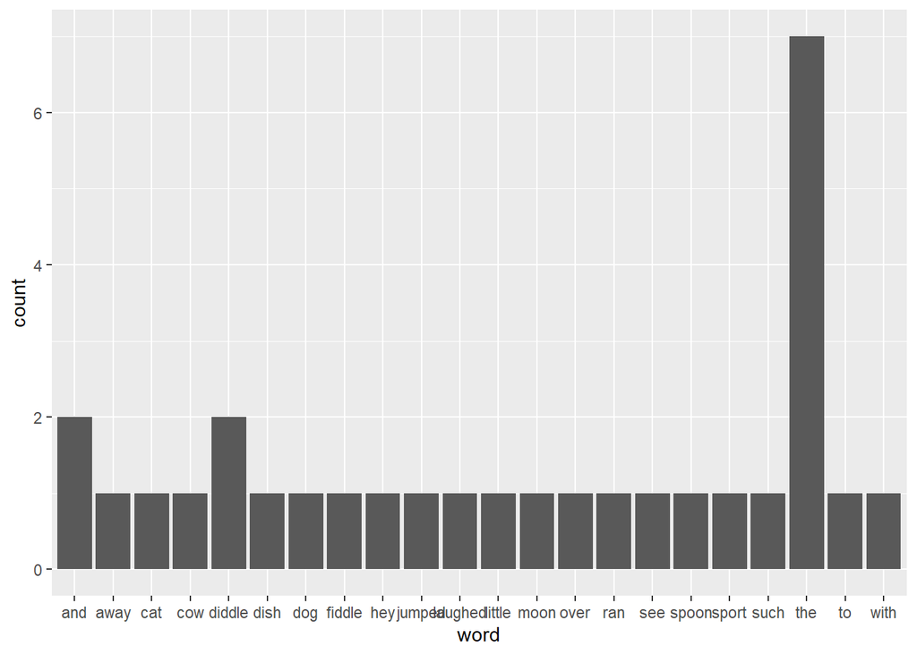

```r
#This is not pretty, but gets the idea across
rhyme %>%
  unnest_tokens(output = "word", input = "text", token = "words") %>%
  ggplot(aes(x = word)) +
  geom_bar()
```

What about a cumulative distribution? We can do this with counts or by frequency (percents) Here is one way to do it with counts

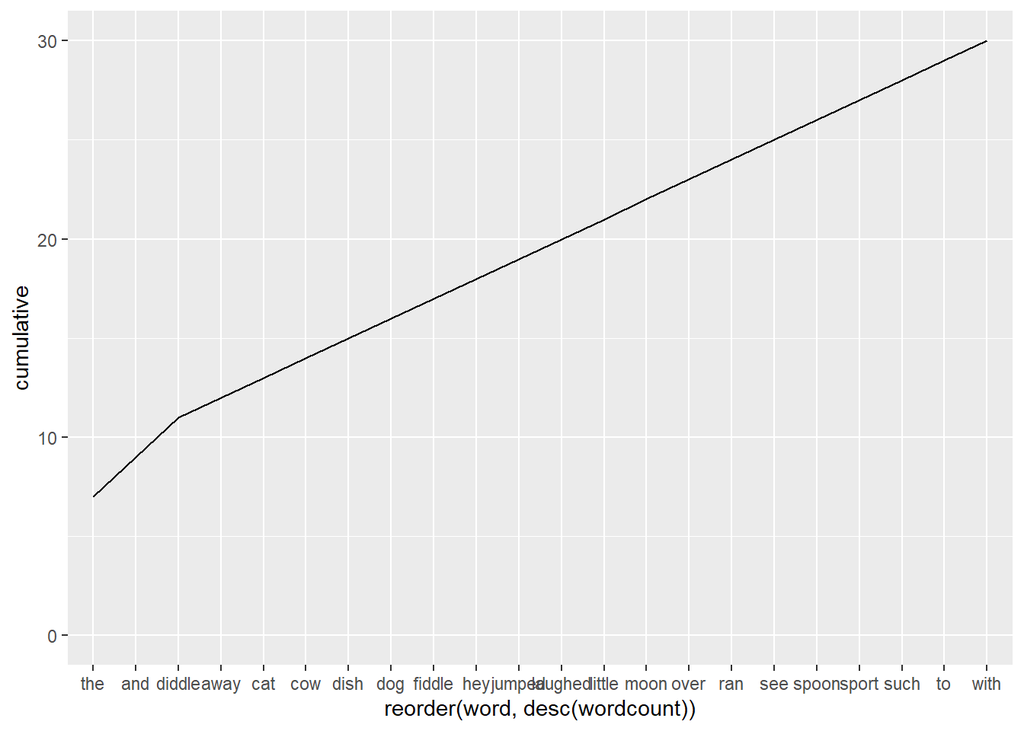

```r
#This graph also could use some cleanup

#This style of plot also needs a little more prep work, like...
#establishing counts
#setting up a cumulative count (in order) for the y-values
#setting up a grouping column for the x-values
#  (otherwise, a line graph won't render, because x is categorical)
rhyme %>%
  unnest_tokens(output = "word", input = "text", token = "words") %>%
  count(word, name = "wordcount") %>%
  arrange(desc(wordcount)) %>%
  mutate(cumulative = cumsum(wordcount),
         title = "rhyme") %>% #this is my grouping variable
  ggplot(aes(x = reorder(word, desc(wordcount)),
             y = cumulative, group = title)) +
  #geom_point() +
  geom_line() +
  scale_y_continuous(limits = c(0,30))
```

Here is one way to do it with percents Empirical Cumulative Distribution

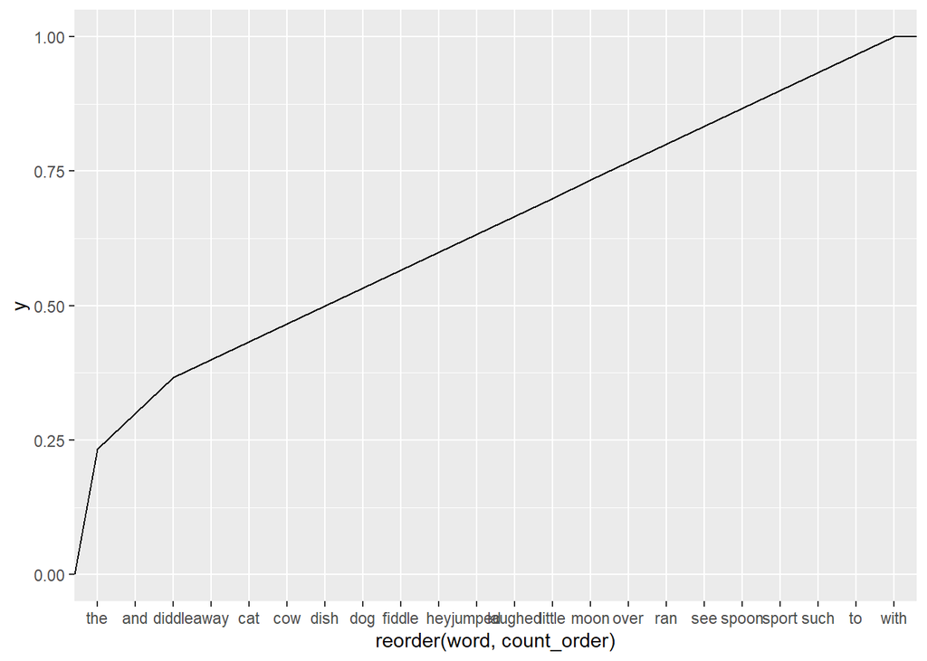

```r
#get wordcounts, put in order
rhyme_counts <- rhyme %>%
  unnest_tokens(output = "word", input = "text", token = "words") %>%
  mutate(title = "rhyme") %>%
  count(word, name = "wordcount") %>%
  arrange(desc(wordcount), word) %>%
  mutate(count_order = row_number())

#apply back to the regular dataframe
rhyme %>%
  unnest_tokens(output = "word", input = "text", token = "words") %>%
  left_join(rhyme_counts, by = "word") %>%
  mutate(title = "rhyme") %>%
  ggplot(aes(x = reorder(word, count_order), group = "title")) +
  stat_ecdf(geom = "line")
```

## Regular Expressions

Let’s talk about that pattern match from last class What was happening?

`mutate( linenumber = row_number(), chapter = cumsum(str_detect( text, regex("^[IVX]*\\.$", ignore_case = FALSE) )), book = cumsum(str_detect( text, regex("^BOOK [\\w]", ignore_case = FALSE) )) )`

Let’s simplify our starting data and look at how this workds

```r
test <- c("IV.", "X.", "VI", "Pope Leo IV", "Pope Leo II.", "Pope Leo XIV!")

#what if we just look for the letters of Roman numerals?
str_subset(string = test, pattern = "IVX")
```

```
## character(0)
```

Hmmm. We don’t want to look for the specific pattern “IVX”, we want to look for those letters in any combination, but only those 3 letters. Let’s see what it matches to

```r
# the brackets are say "match any one of the characters inside"
# the + says "match 1 or more times"
# so together, this says "match one or more of the letters I, V, X"

#the pattern it finds:
str_extract(string = test, pattern = "[IVX]+")
```

```
## [1] "IV"  "X"   "VI"  "IV"  "II"  "XIV"
```

```r
#remember the starting string
#test <- c("IV.", "X.", "VI", "Pope Leo IV", "Pope Leo II.", "Pope Leo XIV!")
```

Let’s see the whole string that has the match

```r
#the whole string it finds
str_subset(string = test, pattern = "[IVX]+")
```

```
## [1] "IV."           "X."            "VI"            "Pope Leo IV"
## [5] "Pope Leo II."  "Pope Leo XIV!"
```

```r
#remember the starting string
#test <- c("IV.", "X.", "VI", "Pope Leo IV", "Pope Leo II.", "Pope Leo XIV!")
```

What if we only want strings that start with those letters?

```r
#we can add a start anchor ^
str_subset(string = test, pattern = "^[IVX]+")
```

```
## [1] "IV." "X."  "VI"
```

```r
#remember the starting string
#test <- c("IV.", "X.", "VI", "Pope Leo IV", "Pope Leo II.", "Pope Leo XIV!")
```

What if we only want strings that contain those specific letters?

```r
#anchor both sides
str_subset(string = test, pattern = "^[IVX]+$")
```

```
## [1] "VI"
```

```r
#remember the starting string
#test <- c("IV.", "X.", "VI", "Pope Leo IV", "Pope Leo II.", "Pope Leo XIV!")
```

What if want to find the popes?

```r
#we can add explicit exact strings to our search
str_subset(string = test, pattern = "^Pope Leo [IVX]+$")
```

```
## [1] "Pope Leo IV"
```

```r
#remember the starting string
#test <- c("IV.", "X.", "VI", "Pope Leo IV", "Pope Leo II.", "Pope Leo XIV!")
```

Why didn’t we get the other Popes? Can we get Leo II?

```r
#Try adding the .
str_subset(string = test, pattern = "^Pope Leo [IVX]+.$")
```

```
## [1] "Pope Leo IV"   "Pope Leo II."  "Pope Leo XIV!"
```

```r
#remember the starting string
#test <- c("IV.", "X.", "VI", "Pope Leo IV", "Pope Leo II.", "Pope Leo XIV!")
```

Why did we get ALL of the popes? Because . in regex matches any character. To match a period, we have to add the “escape” character

```r
#we can add an end anchor $
str_subset(string = test, pattern = "^Pope Leo [IVX]+\.$")

#remember the starting string
#test <- c("IV.", "X.", "VI", "Pope Leo IV", "Pope Leo II.", "Pope Leo XIV!")
```

That just throws an error… because in R, we have to escape escapes. (This is due to how R stores and recognizes punctuation characters) My method: keep adding until it works

```r
#we can add an end anchor $
str_subset(string = test, pattern = "^Pope Leo [IVX]+\\.$")
```

```
## [1] "Pope Leo II."
```

```r
#remember the starting string
#test <- c("IV.", "X.", "VI", "Pope Leo IV", "Pope Leo II.", "Pope Leo XIV!")
```

What if we have more popes, and we want to pull out only John and Francis?

```r
more_popes <- c("Pope Leo IV", "Pope Leo II.", "Pope Leo XIV!", "Pope John II", "Pope John III.", "Pope Francis I.")

#We can use | to mean "or"
str_subset(string = more_popes, pattern = "John|Francis")
```

```
## [1] "Pope John II"    "Pope John III."  "Pope Francis I."
```

And what if we also want to limit to John/Francis popes with punctuation?

```r
#when you want "or" in combination with other regex, wrap your "or" stuff in () to group it
#because this one is more complicated, we also have to add back other regex details
str_subset(string = more_popes, pattern = "(John|Francis) [XIV]+\\.")
```

```
## [1] "Pope John III."  "Pope Francis I."
```

If you want to ignore case, you can wrap the whole “pattern” section as follows and add an argument:

```r
#change TRUE to FALSE or j to J to see what happens
str_subset(string = more_popes, regex(pattern = "(john|francis) [XIV]+\\.", ignore_case = TRUE))
```

```
## [1] "Pope John III."  "Pope Francis I."
```